# Lab: Choropleth Map

Xuemao Zhang

June 27, 2019

## Introduction

- In this session, we use one example to show how to plot a choropleth map using the information for coloring all regions.
- We use the package `usmap` plot US map including Alaska and Hawaii. You may try to use the package `fiftystater`.
- Install the following packages if you don’t have them.

```
                install.packages("devtools");
                devtools::install_github("wmurphyrd/fiftystater");
                install.packages("usmap");
                install.packages("dplyr");
                install.packages('ggplot2');
                install.packages('magick');
                install.packages('stringr');
```

- Consider the state and county unemployment rates data in US from 1990 to 2017. The data are available from [Bureau of Labor Statistics](https://www.bls.gov/lau/).

## Unemployment Data

### State Data

- The state unemployment data (2013-2017) are in the form of HTML tables on https://www.bls.gov/lau/:

  ```
  - https://www.bls.gov/lau/lastrk13.htm
  - https://www.bls.gov/lau/lastrk14.htm
  - https://www.bls.gov/lau/lastrk15.htm
  - https://www.bls.gov/lau/lastrk16.htm
  - https://www.bls.gov/lau/lastrk17.htm
  ```

- The data were downloaded and combined in the file `StateUnemployment.csv`.

```r
StateRate = read.csv("F:/DataCamp/data/StateUnemployment.csv",header=TRUE, sep=",");
dim(StateRate);
```

```
## [1] 255   3
```

```r
str(StateRate);
```

```
## 'data.frame':    255 obs. of  3 variables:
##  $ State: Factor w/ 51 levels "Alabama","Alaska",..: 35 28 42 46 45 16 51 12 24 30 ...
##  $ Rate : num  2.9 3.8 3.8 4.4 4.6 4.7 4.7 4.9 5 5.1 ...
##  $ Year : int  2013 2013 2013 2013 2013 2013 2013 2013 2013 2013 ...
```

### County Data

- The county data from 1990 to 2017 were downloaded and combined in the file `CountyUnemployment.csv`.

```r
library(dplyr);
CountyRate = read.csv("F:/DataCamp/data/CountyUnemployment.csv",header=TRUE, sep=",",stringsAsFactors = FALSE);
dim(CountyRate);
```

```
## [1] 90088     9
```

```r
str(CountyRate);
```

```
## 'data.frame':    90088 obs. of  9 variables:
##  $ LAUS      : chr  "CN0100100000000" "CN0100300000000" "CN0100500000000" "CN0100700000000" ...
##  $ StateFips : int  1 1 1 1 1 1 1 1 1 1 ...
##  $ CountyFips: int  1 3 5 7 9 11 13 15 17 19 ...
##  $ County    : chr  "Autauga County, AL" "Baldwin County, AL" "Barbour County, AL" "Bibb County, AL" ...
##  $ Year      : int  1990 1990 1990 1990 1990 1990 1990 1990 1990 1990 ...
##  $ LaborForce: chr  "16908" "46824" "11490" "7434" ...
##  $ Employed  : chr  "15813" "44379" "10592" "6758" ...
##  $ Unemployed: chr  "1095" "2445" "898" "676" ...
##  $ Rate      : chr  "6.5" "5.2" "7.8" "9.1" ...
```

```r
CountyRate$Rate=as.numeric(CountyRate$Rate);
which(complete.cases(CountyRate)==F);  #some counties in some year have missing values
```

```
##  [1] 49387 49397 49399 49405 49406 49409 49413 52604 52614 52616 52622
## [12] 52623 52626 52630
```

## Visualization of State Data

### Plot the data by year

- For example, we plot the unemployment rate data for the year 2017.

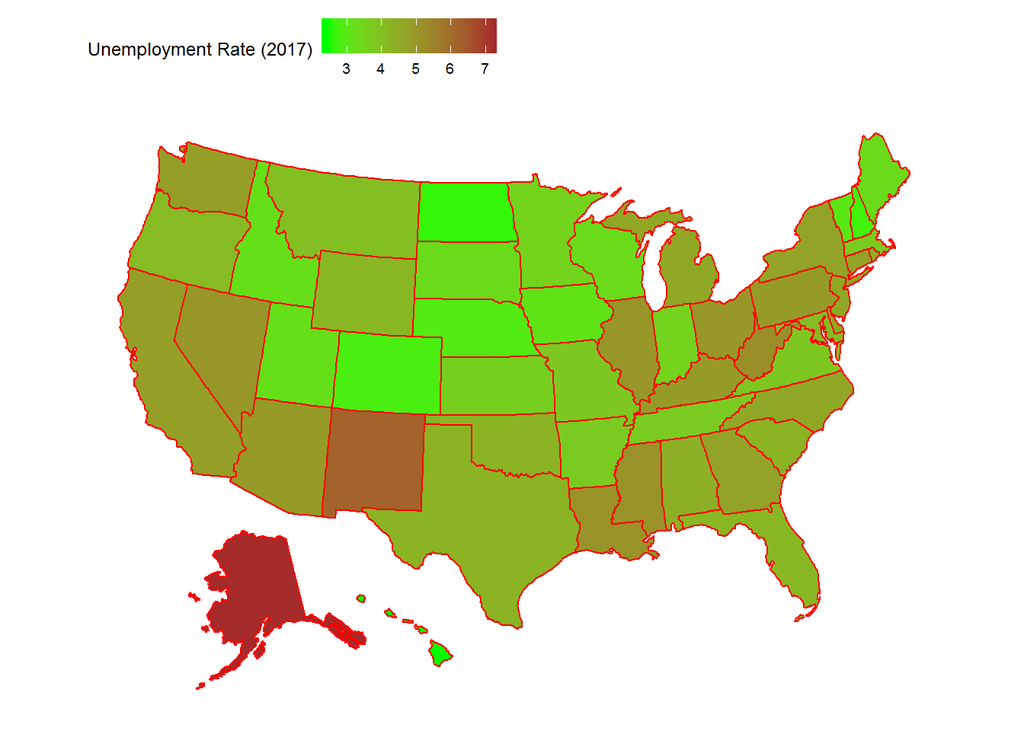

```r
library(usmap);
library(ggplot2);
library(dplyr);
StateRate=dplyr::rename(StateRate, state=State); #rename "State" to "state" to use the usmap package
StateRate_2017=dplyr::filter(StateRate,Year==2017);
plot_usmap(data = StateRate_2017, values = "Rate", lines = "red") +
scale_fill_continuous(low = "green", high = "brown",
name = "Unemployment Rate (2017)", label = scales::comma)+
theme(legend.position = "top");
```

- Now, we plot the unemployment rate data by Year. For this, we define a function of year.

```r
PlotRate= function(x)
{
data_year=dplyr::filter(StateRate, Year == x);
plot_usmap(data = data_year, values = "Rate", lines = "red") +
scale_fill_continuous(low = "green", high = "brown", name = "Rate", label = scales::comma)+
ggtitle(paste("Distribution of US Unemployment Rate in Year",x))+
theme(legend.position = "top");
}
```

- Show all 5 maps.

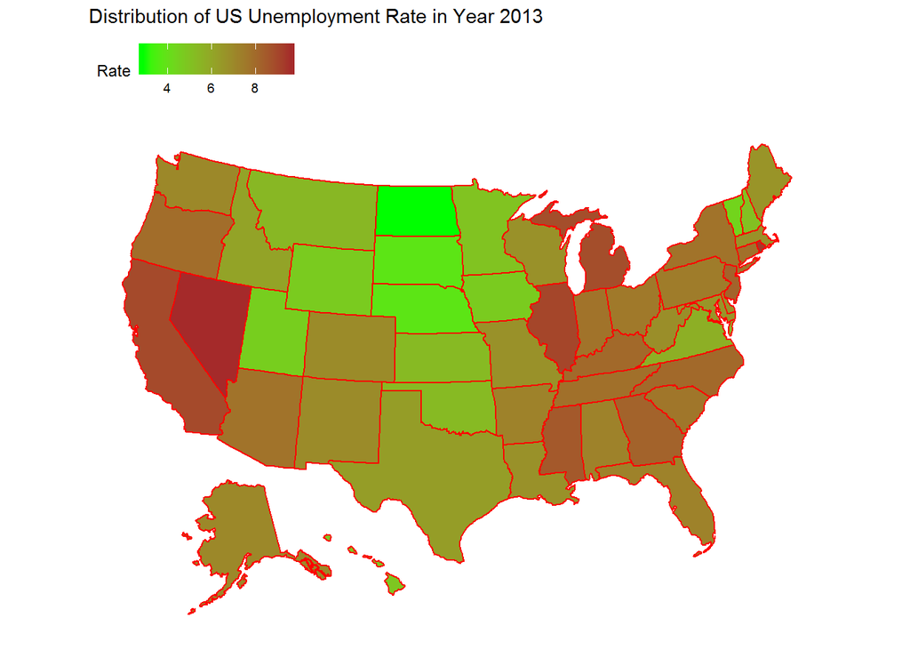

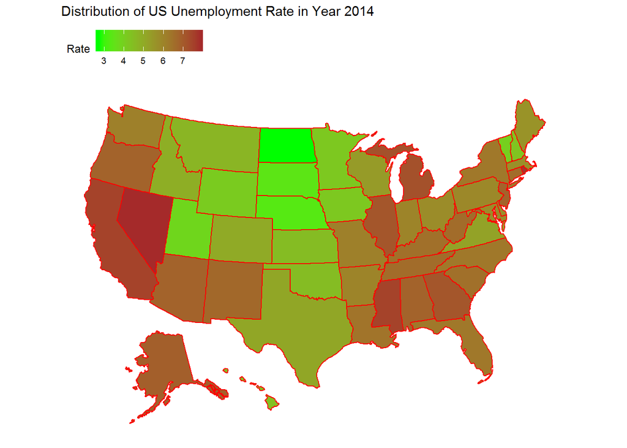

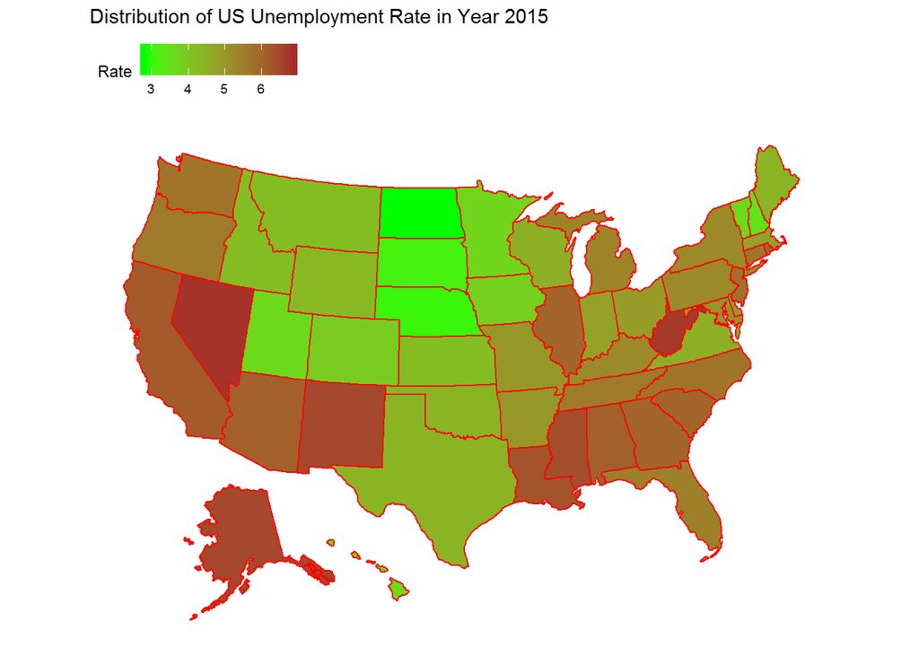

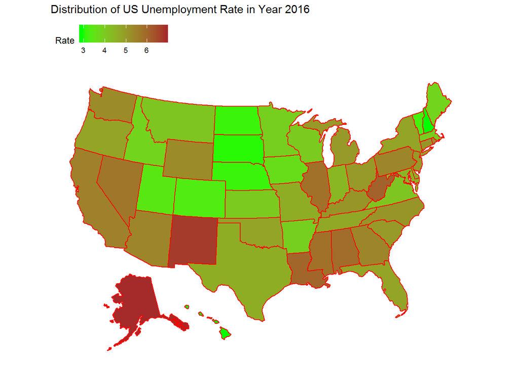

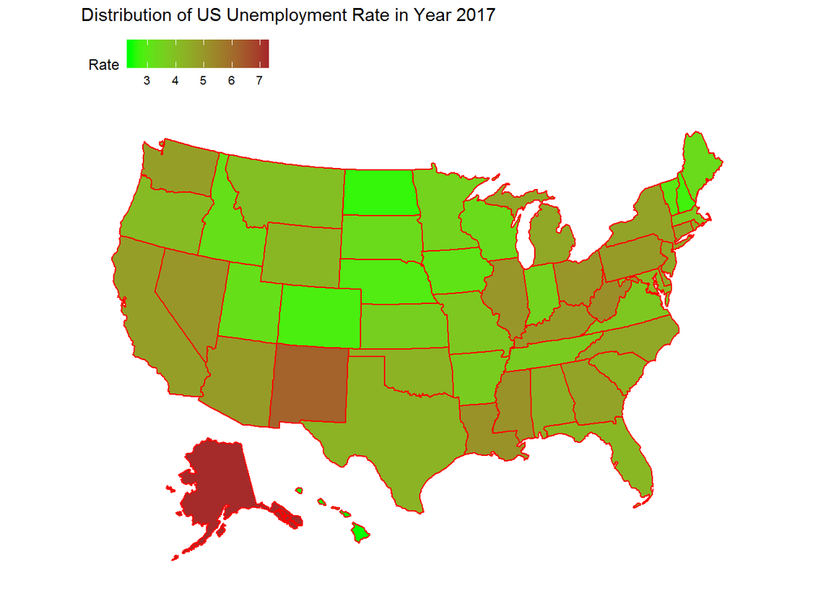

```r
for( i in 1:5)
{
print(PlotRate(i+2012));
}
```

### Animated maps

```r
library(magick);
```

```r
img=image_graph(width=600,height=400,res=96);
for( i in 1:5) print(PlotRate(i+2012));
dev.off();
```

```
## # A tibble: 5 x 7
##   format width height colorspace matte filesize density
##   <chr>  <int>  <int> <chr>      <lgl>    <int> <chr>
## 1 gif      600    400 sRGB       TRUE         0 72x72
## 2 gif      600    400 sRGB       TRUE         0 72x72
## 3 gif      600    400 sRGB       TRUE         0 72x72
## 4 gif      600    400 sRGB       TRUE         0 72x72
## 5 gif      600    400 sRGB       TRUE         0 72x72
```

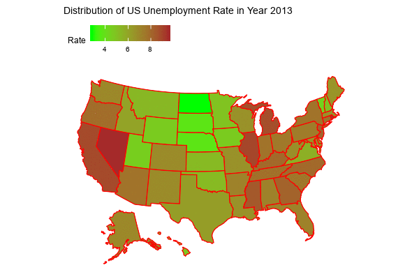

```r
StateAnimation = image_animate(img, fps = 1);
print(StateAnimation);
```

## Visualization of County Data

- Add a variable “state”. You may follow the last section to plot the state level data.

```r
library(stringr);  library(dplyr);
CountyRate=mutate(CountyRate, state=stringr::str_sub(County, -2, -1));  #extract the state name: the last two characters in "County"
head(CountyRate);
```

```
##              LAUS StateFips CountyFips             County Year LaborForce
## 1 CN0100100000000         1          1 Autauga County, AL 1990      16908
## 2 CN0100300000000         1          3 Baldwin County, AL 1990      46824
## 3 CN0100500000000         1          5 Barbour County, AL 1990      11490
## 4 CN0100700000000         1          7    Bibb County, AL 1990       7434
## 5 CN0100900000000         1          9  Blount County, AL 1990      19168
## 6 CN0101100000000         1         11 Bullock County, AL 1990       4407
##   Employed Unemployed Rate state
## 1    15813       1095  6.5    AL
## 2    44379       2445  5.2    AL
## 3    10592        898  7.8    AL
## 4     6758        676  9.1    AL
## 5    17955       1213  6.3    AL
## 6     3859        548 12.4    AL
```

- Add the variable ‘fips’ for county fips following the last lecture.

```r
library(dplyr);
CountyRate$StateFips=as.character(CountyRate$StateFips);
CountyRate$CountyFips=as.character(CountyRate$CountyFips);
CountyRate=mutate( CountyRate, fips=ifelse(nchar(CountyFips)==3,
paste(StateFips, CountyFips, sep=""),
ifelse(nchar(CountyFips)==2,
paste(StateFips, CountyFips, sep="0"),
paste(StateFips, CountyFips, sep="00")))  );
head(CountyRate);
```

```
##              LAUS StateFips CountyFips             County Year LaborForce
## 1 CN0100100000000         1          1 Autauga County, AL 1990      16908
## 2 CN0100300000000         1          3 Baldwin County, AL 1990      46824
## 3 CN0100500000000         1          5 Barbour County, AL 1990      11490
## 4 CN0100700000000         1          7    Bibb County, AL 1990       7434
## 5 CN0100900000000         1          9  Blount County, AL 1990      19168
## 6 CN0101100000000         1         11 Bullock County, AL 1990       4407
##   Employed Unemployed Rate state fips
## 1    15813       1095  6.5    AL 1001
## 2    44379       2445  5.2    AL 1003
## 3    10592        898  7.8    AL 1005
## 4     6758        676  9.1    AL 1007
## 5    17955       1213  6.3    AL 1009
## 6     3859        548 12.4    AL 1011
```

- We first divide the unemployment rate into **seven** categories:
  - “<=2%”
  - “>2% and <=4%”
  - “>4% and <=6%”
  - “>6% and <=8%”
  - “>8% and <=10%”
  - “>10% and <=12%”
  - “>12%”

```r
CountyRate= dplyr::mutate(CountyRate,
rate = ifelse(Rate<=2.0, "2% or lower",
       ifelse(Rate>2 & Rate<=4, "2% to 4%",
       ifelse(Rate>4 & Rate<=6, "4% to 6%",
       ifelse(Rate>6 & Rate<=8, "6% to 8%",
       ifelse(Rate>8 & Rate<=10, "8% to 10%",
       ifelse(Rate>10 & Rate<=12, "10% to 12%", "12% or over"
       ))))))
    );
CountyRate$rate=as.factor(CountyRate$rate);
CountyRate$rate=factor(CountyRate$rate, levels = c("12% or over","10% to 12%","8% to 10%","6% to 8%","4% to 6%","2% to 4%", "2% or lower")); #order the factor levels
which(complete.cases(CountyRate$rate)==F);
```

```
##  [1] 49387 49397 49399 49405 49406 49409 49413 52604 52614 52616 52622
## [12] 52623 52626 52630
```

- Now we plot the county data by Year. For this, we define a function of year.

```r
library(usmap);  library(ggplot2);
PlotCountyRate= function(x)
{
County_year=dplyr::filter(CountyRate, Year==x);
plot_usmap(regions="counties",data = County_year, values ="rate", lines=NA) +
ggplot2::scale_fill_brewer(palette="Accent", name ="Unemployment Rate", na.value = "black")+
ggtitle(paste("Distribution of US Unemployment Rate by County in Year",x))+
theme(legend.position = "right");
}
```

- Animated maps.

```r
library(magick);
img=image_graph(width=600,height=400,res=96);
for( i in 1:28) print(PlotCountyRate(i+1989));
dev.off();
```

```
## # A tibble: 28 x 7
##    format width height colorspace matte filesize density
##    <chr>  <int>  <int> <chr>      <lgl>    <int> <chr>
##  1 gif      600    400 sRGB       TRUE         0 72x72
##  2 gif      600    400 sRGB       TRUE         0 72x72
##  3 gif      600    400 sRGB       TRUE         0 72x72
##  4 gif      600    400 sRGB       TRUE         0 72x72
##  5 gif      600    400 sRGB       TRUE         0 72x72
##  6 gif      600    400 sRGB       TRUE         0 72x72
##  7 gif      600    400 sRGB       TRUE         0 72x72
##  8 gif      600    400 sRGB       TRUE         0 72x72
##  9 gif      600    400 sRGB       TRUE         0 72x72
## 10 gif      600    400 sRGB       TRUE         0 72x72
## # ... with 18 more rows
```

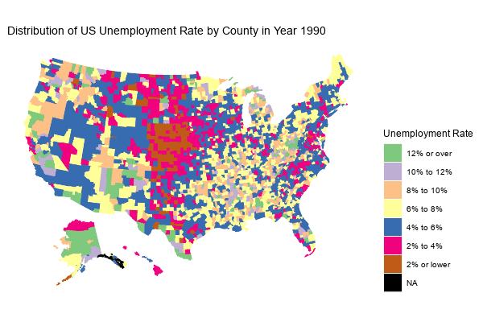

```r
CountyRateAnimation = image_animate(img, fps = 1);
print(CountyRateAnimation);
```

```r
image_write(CountyRateAnimation, "CountyRateAnimation.gif")
```